# Examen Parcial

Alfredo Lefranc

19 de octubre de 2020

Nota: Para este examen me basé en los códigos vistos en clase y los que realicé en las tareas 1 y 2. Sobra decir que también me apoyé en foros de internet, como *Stack Overflow*.

## Presentación de los datos

El primer paso es limpiar el ambiente de trabajo y cargar las librerías básicas que voy a usar.

Cargo el archivo `metadata.R` generado en el ejercicio anterior, junto con el archivo `utils.R`.

```r
source("metadata.R"  , encoding = 'UTF-8')
source("utils.R"     , encoding = 'UTF-8')
```

Al cargar la base aparecen una serie de advertencias.

```r
imports <- read_csv("imports-85.csv",
                      col_names = colnames_imports,
                      na = 'XXXXXXX')
```

```
## Warning: 6 parsing failures.
## row col   expected     actual             file
##  58  -- 26 columns 25 columns 'imports-85.csv'
##  62  -- 26 columns 25 columns 'imports-85.csv'
##  72  -- 26 columns 25 columns 'imports-85.csv'
##  84  -- 26 columns 25 columns 'imports-85.csv'
## 120  -- 26 columns 25 columns 'imports-85.csv'
## ... ... .......... .......... ................
## See problems(...) for more details.
```

```r
problems(imports)
```

| row | col | expected | actual | file |
| --- | --- | --- | --- | --- |
| 58 | NA | 26 columns | 25 columns | 'imports-85.csv' |
| 62 | NA | 26 columns | 25 columns | 'imports-85.csv' |
| 72 | NA | 26 columns | 25 columns | 'imports-85.csv' |
| 84 | NA | 26 columns | 25 columns | 'imports-85.csv' |
| 120 | NA | 26 columns | 25 columns | 'imports-85.csv' |
| 147 | NA | 26 columns | 25 columns | 'imports-85.csv' |

Sucede el mismo problema que nos topamos en el ejemplo de algas. El problema puede observarse en la fila 58:

```r
imports[58,]
```

| symboling | normalized-losses | make | fuel-type | aspiration | num-of-doors | body-style | drive-wheels | engine-location | wheel-base | length | width | height | curb-weight | engine-type | num-of-cylinders | engine-size | fuel-system | bore | stroke | compression-ratio | horsepower | peak-rpm | city-mpg | highway-mpg | price |
| --- | --- | --- | --- | --- | --- | --- | --- | --- | --- | --- | --- | --- | --- | --- | --- | --- | --- | --- | --- | --- | --- | --- | --- | --- | --- |
| 3 | 150 | mazda | gas | std | two | hatchback | rwd | front | 95.3 | 169 | 65.7 | 49.6 | 2385rotor | two | 70 | 4bbl | ? | ? | 9.4 | 101 | 6000 | 17 | 23 | 13645 | NA |

La columna `curb_weight` (columna 14), tiene unidas a dos celdas. Es necesario separarlas. Se repite el procedimiento visto en clase, con las modificaciones necesarias para que no hayan incompatibilidades en los tipos de datos. El procedimiento incluye la limpieza previa de los nombres de las columnas para poder manipular los datos.

```r
colnames(imports) <- colnames_imports

colnames(imports) <- imports_clean_colnames(colnames_imports)

# función
imports_clean_colnames <- function(x){
  str_replace_all(tolower(x),"[-]", "_")
}


problematic_rows <- readr::problems(imports)$row

imports[problematic_rows,] <- imports %>%
  slice(problematic_rows) %>%
  unite(col='all', -seq(1:13), sep = "/", remove=TRUE) %>%
  extract('all', into = c("curb_weight", "engine_type", 'resto'),
          regex="([0-9]*)([a-z]*)/(.*)/NA", remove=TRUE) %>%
  separate('resto', into=names(imports)[16:26], sep="/", remove=TRUE) %>%
  readr::type_convert() %>%
  mutate(across(c("wheel_base",
                  "price",
                  "peak_rpm",
                  "horsepower",
                  "engine_size",
                  "curb_weight"),
                as.character))
```

Al revisar cómo quedan los datos, noto que la variable `wheel_base` es de texto cuando debería ser numérica. Revisando los datos, encuentro que el problema es una observación escrita en texto. Hago la corrección. Además, la categoría de mercedes-benz en `make` aparece dos veces por un typo.

```r
imports$wheel_base[imports$wheel_base == "ninetyfivedot7"] <- "95.7"
imports_data$make[imports_data$make == "mercedes-bens"] <- "mercedes-benz"
```

Una vez corregido esto, hago la conversión de tipo de datos manualmente para que las variables leídas incorrectamente sean corregidas por R. Antes, claro, deben reemplazarse los `?` por `NA's`.

```r
# función
imports_clean_data <- function(x){
  str_replace_all(tolower(x),"[?]", replacement = NA_character_)
}

imports <- imports %>%
  mutate_at(c(2,6,19,20,22,23,26), list(imports_clean_data))


imports <- readr::type_convert(imports)

imports  <- imports %>%
  mutate_at(c(1,3:9,15,16,18),list(as.factor))
```

Con el último comando convierto las variables de texto a variables categóricas, y también la variable `symboling`:

Los pasos anteriores en realidad los corro con los archivos por separado, como pide el ejercicio 1.2 (el código es el mismo, sólo que en este documento uso la base `imports` como ejemplo para no confundir con la base que se usa en adelante, `imports_data`:

```r
source("00-load.R"   , encoding = 'UTF-8')
source("01-prepare.R", encoding = 'UTF-8')
source("02-clean.R",   encoding = 'UTF-8')
```

Después de correr los archivos separados para cargar y limpiar la base, reviso que las variables sean del tipo indicado en el archivo *imports-85.names*.

```r
glimpse(imports_data)
```

```
## Rows: 205
## Columns: 26
## $ symboling         <fct> 3, 3, 1, 2, 2, 2, 1, 1, 1, 0, 2, 0, 0, 0, 1, 0, 0...
## $ normalized_losses <dbl> NA, NA, NA, 164, 164, NA, 158, NA, 158, NA, 192, ...
## $ make              <fct> alfa-romero, alfa-romero, alfa-romero, audi, audi...
## $ fuel_type         <fct> gas, gas, gas, gas, gas, gas, gas, gas, gas, gas,...
## $ aspiration        <fct> std, std, std, std, std, std, std, std, turbo, tu...
## $ num_of_doors      <fct> two, two, two, four, four, two, four, four, four,...
## $ body_style        <fct> convertible, convertible, hatchback, sedan, sedan...
## $ drive_wheels      <fct> rwd, rwd, rwd, fwd, 4wd, fwd, fwd, fwd, fwd, 4wd,...
## $ engine_location   <fct> front, front, front, front, front, front, front, ...
## $ wheel_base        <dbl> 88.6, 88.6, 94.5, 99.8, 99.4, 99.8, 105.8, 105.8,...
## $ length            <dbl> 168.8, 168.8, 171.2, 176.6, 176.6, 177.3, 192.7, ...
## $ width             <dbl> 64.1, 64.1, 65.5, 66.2, 66.4, 66.3, 71.4, 71.4, 7...
## $ height            <dbl> 48.8, 48.8, 52.4, 54.3, 54.3, 53.1, 55.7, 55.7, 5...
## $ curb_weight       <dbl> 2548, 2548, 2823, 2337, 2824, 2507, 2844, 2954, 3...
## $ engine_type       <fct> dohc, dohc, ohcv, ohc, ohc, ohc, ohc, ohc, ohc, o...
## $ num_of_cylinders  <fct> four, four, six, four, five, five, five, five, fi...
## $ engine_size       <dbl> 130, 130, 152, 109, 136, 136, 136, 136, 131, 131,...
## $ fuel_system       <fct> mpfi, mpfi, mpfi, mpfi, mpfi, mpfi, mpfi, mpfi, m...
## $ bore              <dbl> 3.47, 3.47, 2.68, 3.19, 3.19, 3.19, 3.19, 3.19, 3...
## $ stroke            <dbl> 2.68, 2.68, 3.47, 3.40, 3.40, 3.40, 3.40, 3.40, 3...
## $ compression_ratio <dbl> 9.00, 9.00, 9.00, 10.00, 8.00, 8.50, 8.50, 8.50, ...
## $ horsepower        <dbl> 111, 111, 154, 102, 115, 110, 110, 110, 140, 160,...
## $ peak_rpm          <dbl> 5000, 5000, 5000, 5500, 5500, 5500, 5500, 5500, 5...
## $ city_mpg          <dbl> 21, 21, 19, 24, 18, 19, 19, 19, 17, 16, 23, 23, 2...
## $ highway_mpg       <dbl> 27, 27, 26, 30, 22, 25, 25, 25, 20, 22, 29, 29, 2...
## $ price             <dbl> 13495, 16500, 16500, 13950, 17450, 15250, 17710, ...
```

El tipo de todas las variables coincide. Ahora procedo a realizar en análisis exploratorio de los datos.

## EDA

Primero reviso el resumen estadístico:

```r
summary(imports_data)
```

```
##  symboling normalized_losses         make      fuel_type   aspiration
##  -2: 3     Min.   : 65       toyota    : 32   diesel: 20   std  :168
##  -1:22     1st Qu.: 94       nissan    : 18   gas   :185   turbo: 37
##  0 :67     Median :115       mazda     : 17
##  1 :54     Mean   :122       honda     : 13
##  2 :32     3rd Qu.:150       mitsubishi: 13
##  3 :27     Max.   :256       subaru    : 12
##            NA's   :41        (Other)   :100
##  num_of_doors       body_style drive_wheels engine_location   wheel_base
##  four:114     convertible: 6   4wd:  9      front:202       Min.   : 86.60
##  two : 89     hardtop    : 8   fwd:120      rear :  3       1st Qu.: 94.50
##  NA's:  2     hatchback  :70   rwd: 76                      Median : 97.00
##               sedan      :96                                Mean   : 98.76
##               wagon      :25                                3rd Qu.:102.40
##                                                             Max.   :120.90
##
##      length          width           height       curb_weight     engine_type
##  Min.   :141.1   Min.   :60.30   Min.   :47.80   Min.   :  1488   dohc : 12
##  1st Qu.:166.3   1st Qu.:64.10   1st Qu.:52.00   1st Qu.:  2169   dohcv:  1
##  Median :173.2   Median :65.50   Median :54.10   Median :  2420   l    : 12
##  Mean   :174.0   Mean   :65.91   Mean   :53.72   Mean   :  7858   ohc  :148
##  3rd Qu.:183.1   3rd Qu.:66.90   3rd Qu.:55.50   3rd Qu.:  2954   ohcf : 15
##  Max.   :208.1   Max.   :72.30   Max.   :59.80   Max.   :338000   ohcv : 13
##                                                                   rotor:  4
##  num_of_cylinders  engine_size     fuel_system      bore          stroke
##  eight :  5       Min.   : 61.0   mpfi   :94   Min.   :2.54   Min.   :2.070
##  five  : 11       1st Qu.: 97.0   2bbl   :66   1st Qu.:3.15   1st Qu.:3.110
##  four  :159       Median :120.0   idi    :20   Median :3.31   Median :3.290
##  six   : 24       Mean   :126.9   1bbl   :11   Mean   :3.33   Mean   :3.255
##  three :  1       3rd Qu.:141.0   spdi   : 9   3rd Qu.:3.59   3rd Qu.:3.410
##  twelve:  1       Max.   :326.0   4bbl   : 3   Max.   :3.94   Max.   :4.170
##  two   :  4                       (Other): 2   NA's   :4      NA's   :4
##  compression_ratio   horsepower       peak_rpm       city_mpg
##  Min.   : 7.00     Min.   : 48.0   Min.   :4150   Min.   :13.00
##  1st Qu.: 8.60     1st Qu.: 70.0   1st Qu.:4800   1st Qu.:19.00
##  Median : 9.00     Median : 95.0   Median :5200   Median :24.00
##  Mean   :10.14     Mean   :104.3   Mean   :5125   Mean   :25.22
##  3rd Qu.: 9.40     3rd Qu.:116.0   3rd Qu.:5500   3rd Qu.:30.00
##  Max.   :23.00     Max.   :288.0   Max.   :6600   Max.   :49.00
##                    NA's   :2       NA's   :2
##   highway_mpg        price
##  Min.   :16.00   Min.   : 5118
##  1st Qu.:25.00   1st Qu.: 7775
##  Median :30.00   Median :10295
##  Mean   :30.75   Mean   :13207
##  3rd Qu.:34.00   3rd Qu.:16500
##  Max.   :54.00   Max.   :45400
##                  NA's   :4
```

Aquí debe notarse la presencia de NAs.

```r
colnames(imports_data)[colSums(is.na(imports_data)) > 0]
```

```
## [1] "normalized_losses" "num_of_doors"      "bore"
## [4] "stroke"            "horsepower"        "peak_rpm"
## [7] "price"
```

```r
nrow(imports_data[!complete.cases(imports_data),])
```

```
## [1] 46
```

Hay 7 columnas y 46 observaciones con NAs. Replico la función vista en clase para explorar si los NA’s están concentrados en algunas observaciones específicas.

```r
indices_con_NAs <- function(df, porcentaje=0.2) {
    n <- ifelse (porcentaje < 1,
        as.integer(porcentaje  * ncol(df)),
        stop("Introucir el porcentaje de columnas con NAs.")
    )
    indices <- which( apply(df, 1, function(x) sum(is.na(x))) > n )
    if (!length(indices)) {
        warning("No hay observaciones con tantos NAs ")
    }
    indices
}
```

Aplico la función a la base, con un valor crítico de 20%.

```r
indices_con_NAs(imports_data,0.2)
```

```
## integer(0)
```

Esta es una buena noticia. Por el momento los NA’s serán excluidos del EDA, sin quitar observaciones. Éstas simplemente serán ignoradas.

### Gráficas

Para facilitar el análisis, subdivido la base en variables numéricas y categóricas.

```r
imp_num <- imports_data %>%
  dplyr::select_if(is.numeric)

imp_colnames_num <- colnames(imp_num)

imp_fac <- imports_data %>%
  dplyr::select_if(is.factor)

imp_colnames_fac <- colnames(imp_fac)
```

#### Una sola variable

Histogramas y densidad de las variables numéricas

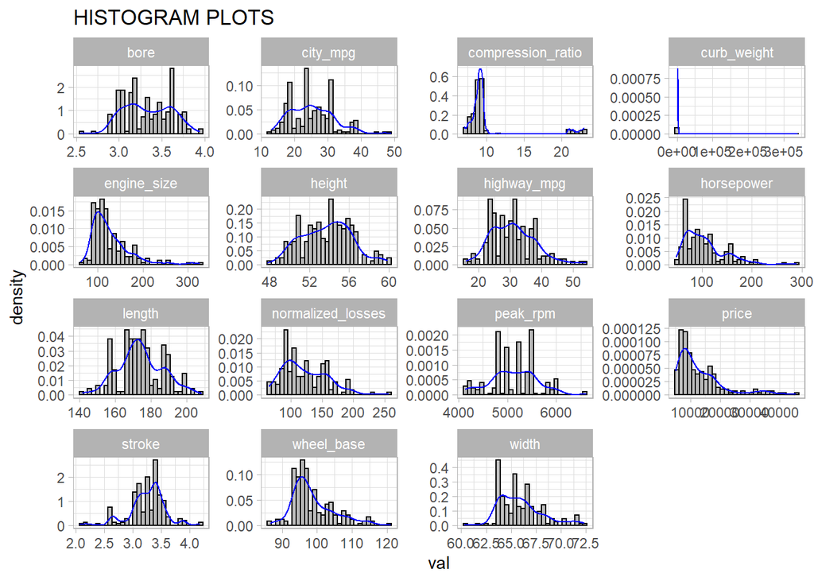

```r
imports_longer <- imp_num %>%
  pivot_longer(cols = all_of(imp_colnames_num),
               names_to = "datos",
               values_to= "val")

hist_plot <- ggplot(imports_longer, aes(val)) +
  geom_histogram((aes(y = ..density..)), color = "black", fill = "gray") +
  geom_density(color = "blue") +
  facet_wrap(~ datos, scales = "free", ncol = 4) +
  ggtitle("HISTOGRAM PLOTS") +
  theme_light() +
  scale_fill_brewer()

hist_plot
```

Aquí podemos notar varios puntos:

Ninguna de las variables parece tener una distribución normal. Esto podemos verificarlo con las gráficas QQ-Plot.

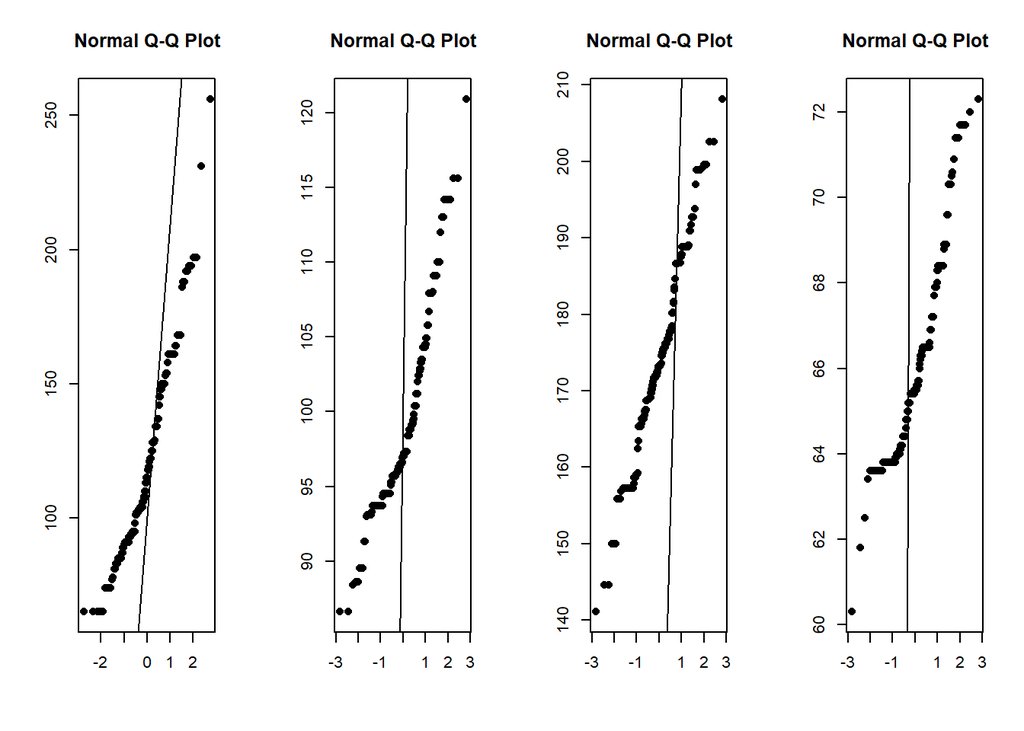

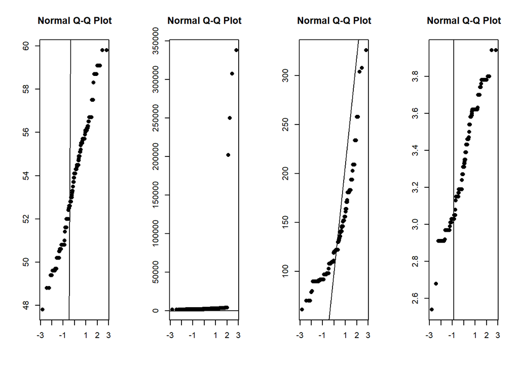

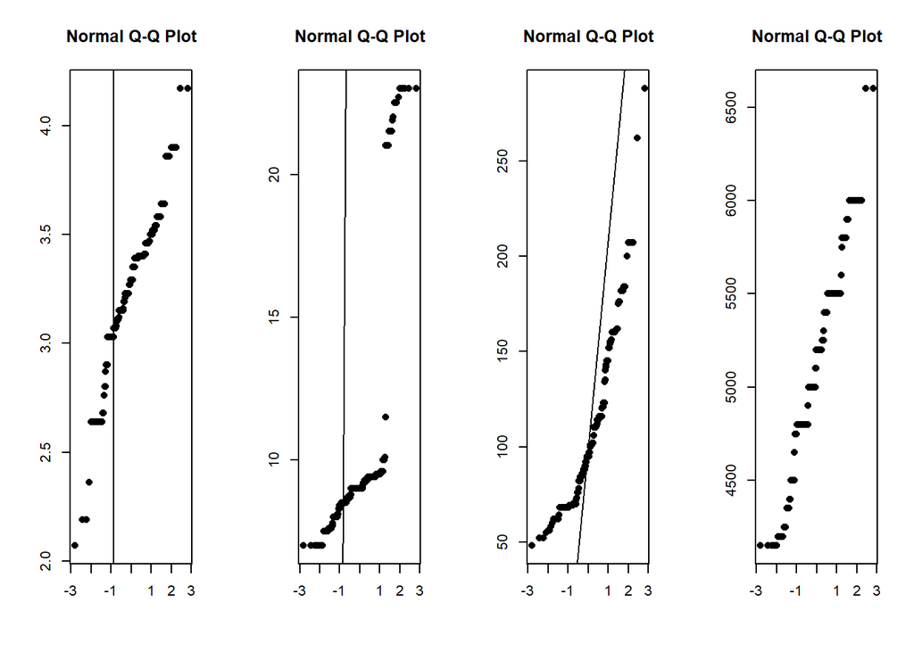

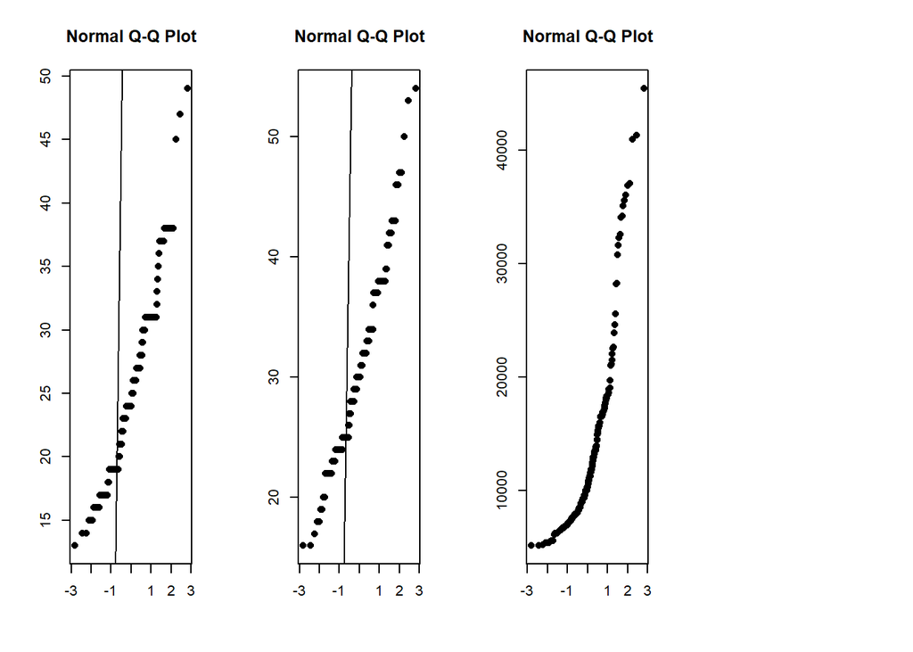

```r
library(purrr)
qqgraph <- function(x){
  qqnorm(x, main=, ylab="", xlab="", pch=16)
  qqline(imp_num)
}

par(mfrow=c(1,4))
map(imp_num, qqgraph)
```

Estas gráficas confirman que ninguna de las variables tiene una distribución normal.

- ¿Outliers?

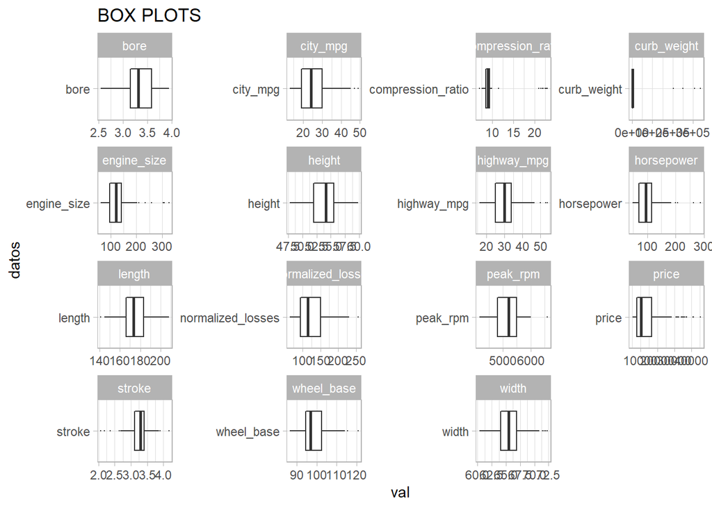

```r
box_plot <- ggplot(imports_longer, aes(x = datos, y = val)) +
  geom_boxplot(outlier.size = .05) +
  facet_wrap(~ datos, scale = "free") +
  coord_flip() +
  ggtitle("BOX PLOTS") +
  theme_light()

box_plot
```

- `bore` y `height` son las únicas variables sin outliers.
- `curb_weight`, `engine_size`, `horsepower` y `price` tienen muchos outliers en la cola derecha, y una propoción alta de valores concentrados del lado izquierdo, sin ser negativos. Esto apunta a una transformación logarítmica de estas variables.

```r
log_imp <- mutate_at(imports_data,c("curb_weight", "engine_size", "horsepower", "price"), log)

imp_num <- log_imp %>%
  dplyr::select_if(is.numeric)

translog <- dplyr::select(log_imp,c("curb_weight", "engine_size", "horsepower", "price"))

log_colnames <- colnames(translog)
```

Vuelvo a graficar los boxplots para las variables transformadas.

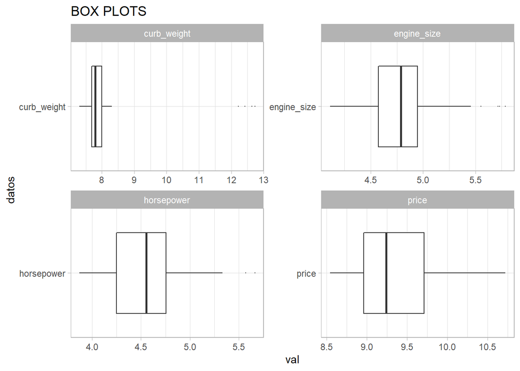

```r
log_longer <- translog %>%
  pivot_longer(cols = all_of(log_colnames),
               names_to = "datos",
               values_to= "val")

box_plot2 <- ggplot(log_longer, aes(x = datos, y = val)) +
  geom_boxplot(outlier.size = .05) +
  facet_wrap(~ datos, scale = "free") +
  coord_flip() +
  ggtitle("BOX PLOTS") +
  theme_light()

box_plot2
```

La distribución de las variables `engine_size`, `horsepower` y `price` se puede apreciar de mejor manera con la transformación, pero para `curb_weight` lo ideal parece ajustar la gráfica para excluir esos valores. ¿Será que hay valores con ceros extra?

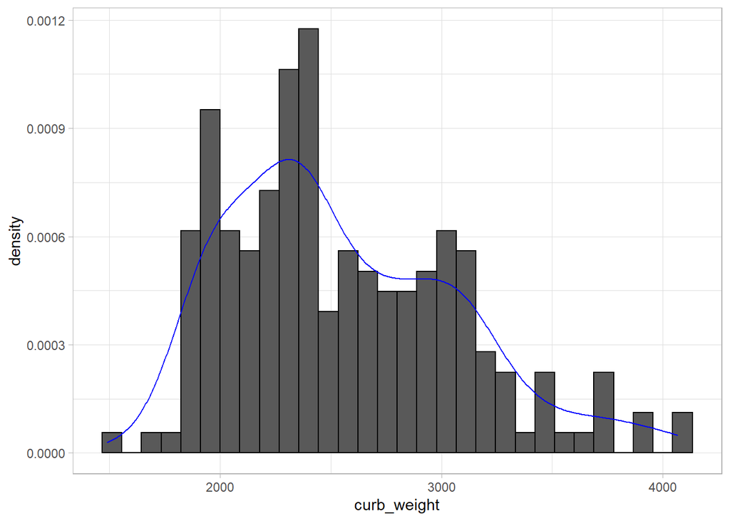

```r
curb <- imports_data %>% filter(curb_weight<50000)
ggplot(curb, aes(curb_weight)) +
  geom_histogram((aes(y=..density..)), color = "black") +
  geom_density(color = "blue") +
  theme_light() +
  scale_fill_brewer()
```

Excluyendo los cuatro valores aberrantes, la distribución de curb_weight se aprecia mucho mejor.

Ahora examinemos la distribución de los datos de acuerdo con las variables categóricas.

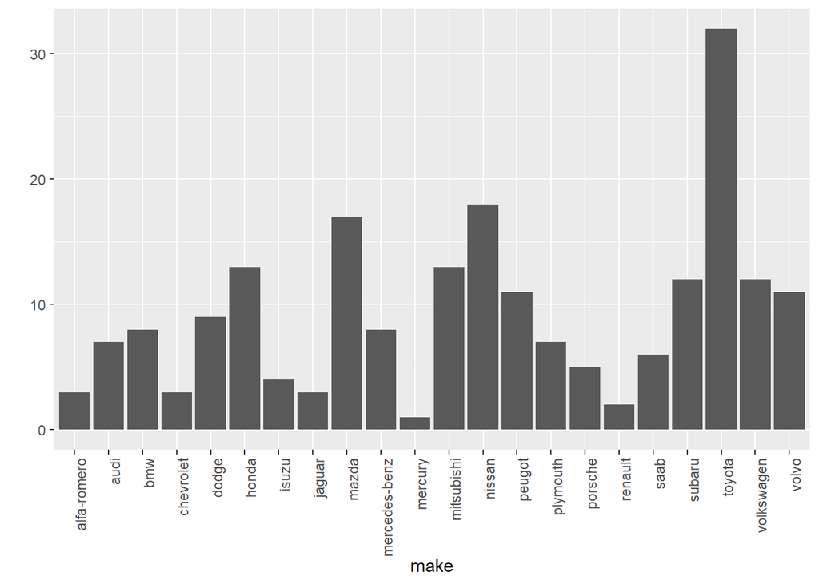

```r
ggplot(imp_fac, aes(make)) + geom_bar() + ylab("") + theme(axis.text.x=element_text(angle=90,hjust=1))
```

Notamos que Toyota es el fabricante más común, seguido por (unas 15 observaciones detrás) Nissan y Mazda; Honda es el cuarto fabricante más popular, los cuatro japoneses.

Ahora grafico las demás variables categóricas con gráficas de barras.

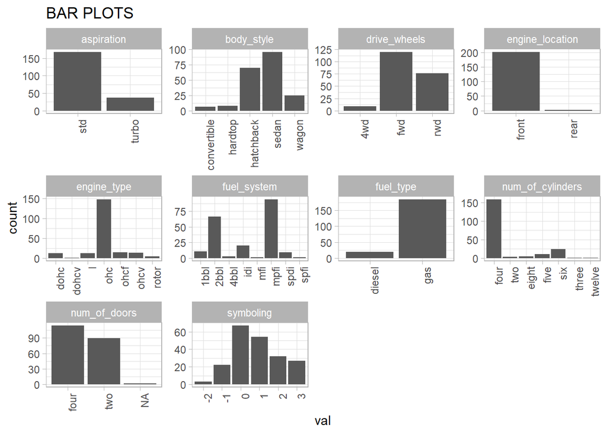

```r
imports_longer2 <- imp_fac[,-2] %>%
  pivot_longer(cols = all_of(imp_colnames_fac[-2]),
               names_to = "datos",
               values_to= "val")

bar_plot <- ggplot(imports_longer2, aes(val)) +
  geom_bar() +
  facet_wrap(~ datos, scales = "free", ncol = 4) +
  ggtitle("BAR PLOTS") +
  theme_light() +
  theme(axis.text.x=element_text(angle=90,hjust=1)) +
  scale_fill_brewer()

bar_plot
```

Los datos están concentrados en varias de las categorías anteriores:

1. `aspiration`: standard
2. motor ubicado en la parte delantera
3. gasolina como combustible
4. 4 cilindros
5. motor tipo ohc
6. un sistema de combustible mpfi o 2bbl

#### Dos variables

Gráfica de barras ilustrativa para la variable `make`.

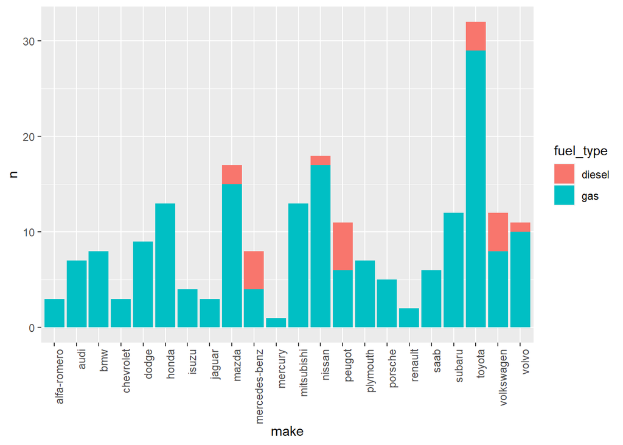

```r
imp_fac %>% count(make, fuel_type) %>%
ggplot(aes(fill=fuel_type, x=make, y=n)) +
  geom_bar(position="stack", stat="identity") +
  theme(axis.text.x=element_text(angle=90,hjust=1))
```

Esta gráfica nos muestra qué fabricantes cuentan con modelos que corren con diesel. Como este ejemplo muestra, `make` puede ser una fuente importante de heterogeneidad en los datos.

A continuación grafico las combinaciones de variables categóricas.

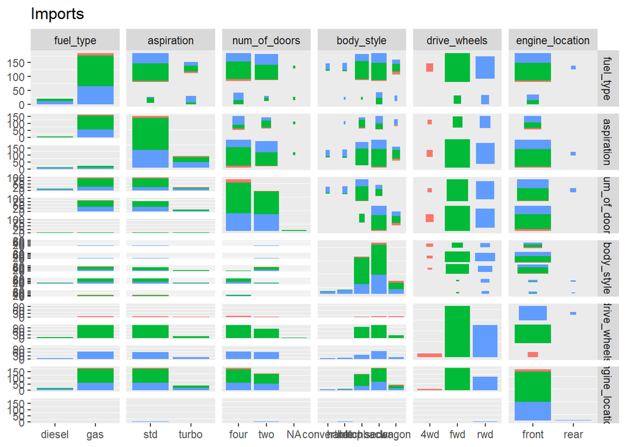

```r
library(GGally)

imp_fac_a <- imp_fac[,c(3:8)]
imp_fac_b <- imp_fac[,c(1,9:11)]

bivar_a <- ggpairs(imp_fac_a,
  title = "Imports",
  mapping = ggplot2::aes(colour = drive_wheels),
      lower = list(continuous = wrap("points",
                                     alpha = 0.3,
                                     size = 0.1,
                                     color = 'blue'),
                   discrete = "facetbar",
                   combo = "facethist"),
      diag = list(discrete ="barDiag",
                  continuous = wrap("densityDiag",
                                    alpha = 0.2,
                                    color = 'blue' )),
      upper = list(combo = wrap("box_no_facet",
                                alpha = 0.5),
                   continuous = wrap("cor",
                                     size = 4,
                                     alignPercent = 0.6))) +
  theme(panel.grid.major = element_blank())

bivar_b <- ggpairs(imp_fac_b,
  title = "Imports",
  mapping = ggplot2::aes(colour = symboling),
      lower = list(continuous = wrap("points",
                                     alpha = 0.3,
                                     size = 0.1,
                                     color = 'blue'),
                   discrete = "facetbar",
                   combo = "facethist"),
      diag = list(discrete ="barDiag",
                  continuous = wrap("densityDiag",
                                    alpha = 0.2,
                                    color = 'blue' )),
      upper = list(combo = wrap("box_no_facet",
                                alpha = 0.5),
                   continuous = wrap("cor",
                                     size = 4,
                                     alignPercent = 0.6))) +
  theme(panel.grid.major = element_blank())


bivar_a
```

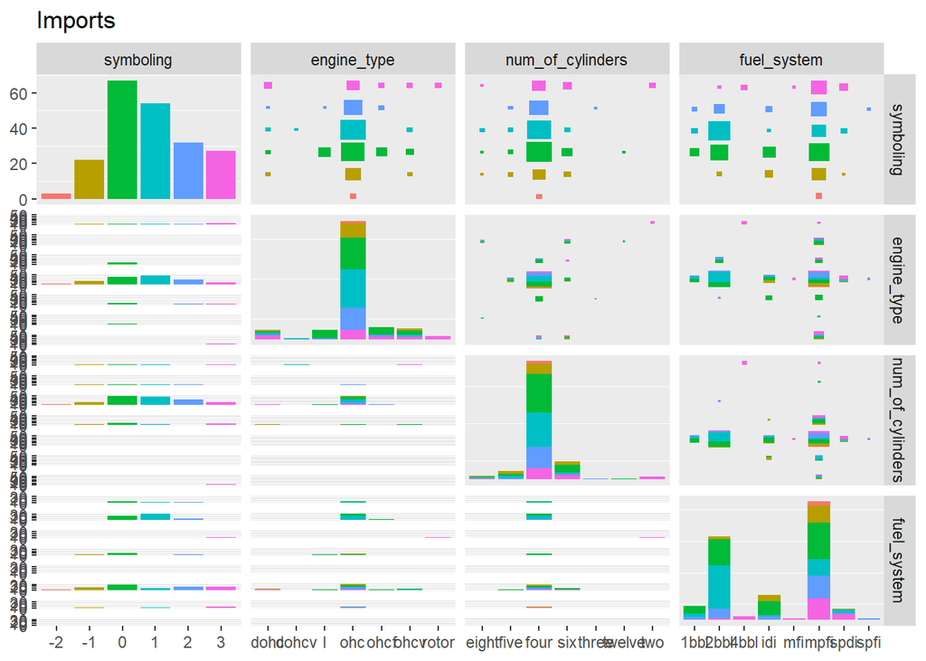

```r
bivar_b
```

Las gráficas muestran barras encimadas sobre la diagonal (menos para `drive_wheels`, que es la variable de relleno, con rojo para 4wd, verde para fwd y azul para rwd). En la parte superior se muestran volúmenes para denotar la proporción de los niveles en cada categoría, de forma cruzada. La parte de abajo muestra barras individuales para cada combinación de categorías, y como puede (no) verse, muchas de las combinaciones son muy escasas. Ambas gráficas muestran ciertas coincidencias en las concentraciones de los datos por categorías. Es decir, las observaciones que están concentradas, por ejemplo, en `fuel_type = gas`, también están concentradas en `aspiration = standard`. Esa coincidencia en concentraciones es particularmente clara, aunque también se observa lo mismo con los autos con motores en la parte delantera, `aspiration = standard`, gasolina como combustible y autos con cuatro puertas. El caso de la segunda gráfica es muy similar.

Continúo con las variables numéricas.

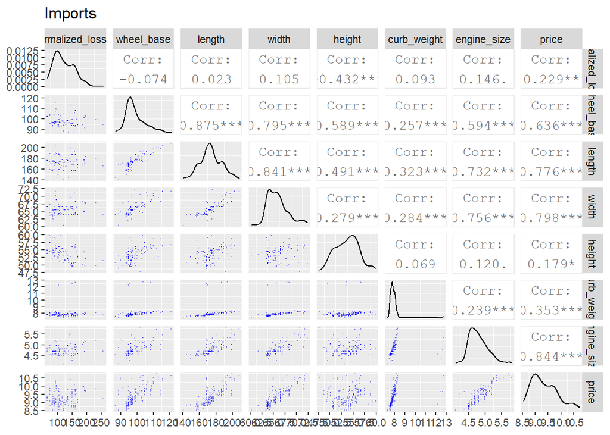

```r
imp_num_a <- imp_num[,c(1:7,15)]
imp_num_b <- imp_num[,8:15]

bivar_num_a <- ggpairs(imp_num_a,
  title = "Imports",
    lower = list(continuous = wrap("points",
                                   alpha = 0.3,
                                   size = 0.1,
                                   color = 'blue')),
    diag = list(continuous = wrap("densityDiag",
                                  alpha = 0.3)),
    upper = list(continuous = wrap("cor", size = 4,
                                   alignPercent = 0.6))) +
  theme(panel.grid.major = element_blank())

bivar_num_b <- ggpairs(imp_num_b,
  title = "Imports",
    lower = list(continuous = wrap("points",
                                   alpha = 0.3,
                                   size = 0.1,
                                   color = 'blue')),
    diag = list(continuous = wrap("densityDiag",
                                  alpha = 0.3)),
    upper = list(continuous = wrap("cor", size = 4,
                                   alignPercent = 0.6))) +
  theme(panel.grid.major = element_blank())

bivar_num_a
```

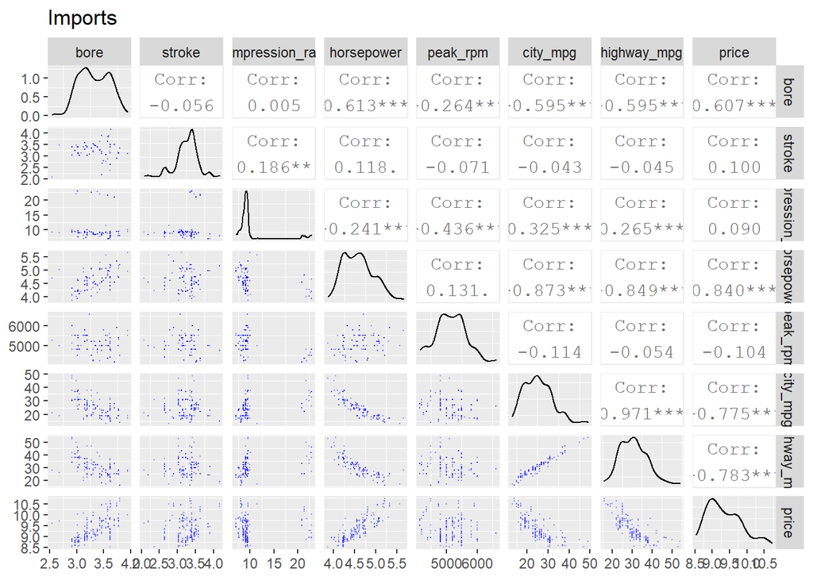

```r
bivar_num_b
```

Como no se cubren todas las combinaciones, agrego esta gráfica. Además, en ésta es más fácil identificar relaciones entre variables por los colores condicionales.

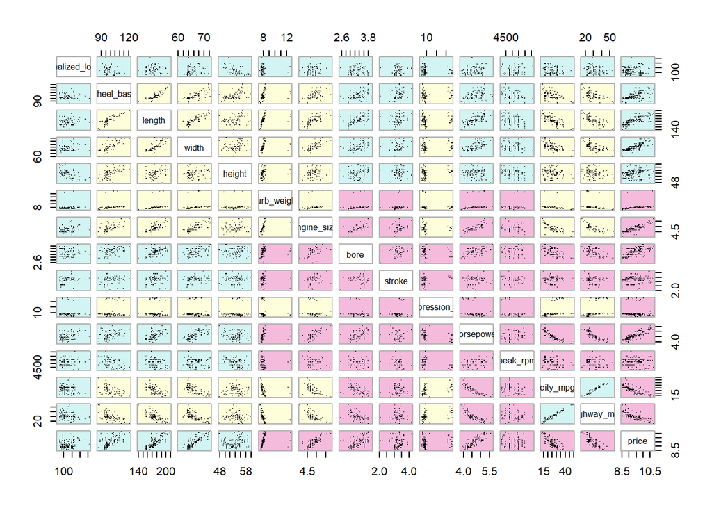

```r
library(gclus)
imp.cor <- cor(imp_num)
imp.color <- dmat.color(imp.cor)
cpairs(imp_num, panel.colors=imp.color,
       pch=".", gap=.5)
```

#### Multivariado

Primero uso la gráfica `ggparcoord` para ver el comportamiento general de las observaciones en relación a sus características.

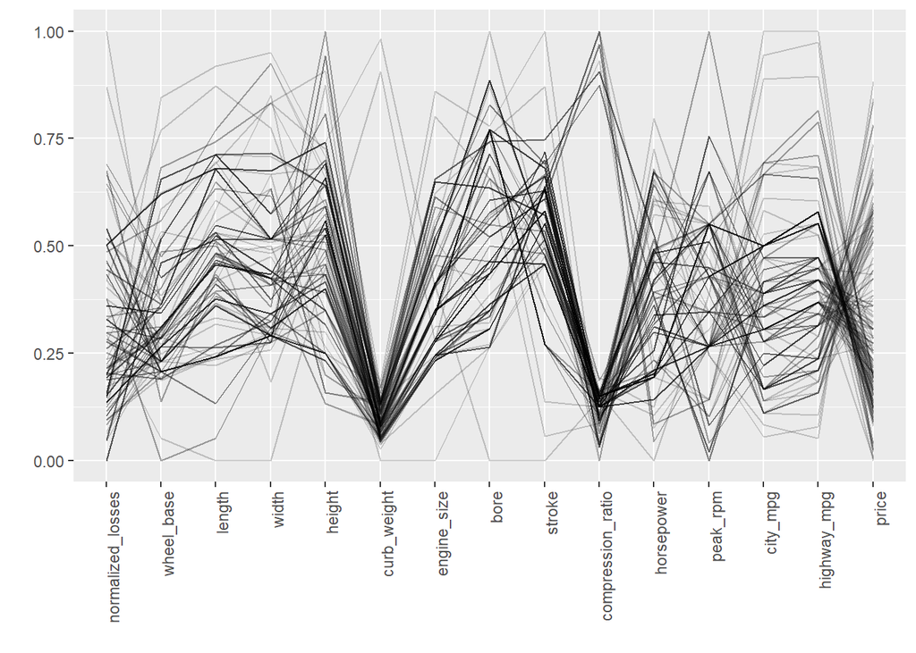

```r
library(GGally)

ggparcoord(data = imp_num, scale="uniminmax", alphaLines=0.2) +
  xlab("") + ylab("") +
  theme(axis.text.x=element_text(angle=90,hjust=1))
```

De manera general, esta gráfica nos muestra lo mismo que el análisis univariado. Hay concentraciones y presencia de valores aberrantes en variables como `ln_curb_weight` y `compression_ratio`. También se nota una relación inversa entre las millas por galón y el precio. Las líneas casi horizontales entre `city_mpg` y `highway_mpg` nos dicen que las variables tienen una correlación muy alta.

Ahora incorporo algunas variables categóricas al análisis. Una de las variables que se usan es `symboling`, y para simplificar el análisis, creo la variable `symbols` con dos niveles, `"safe"` para los niveles no negativos y `"risky"` para los negativos.

```r
symbols <- within(log_imp,
                    safe <- ifelse(symboling == "0" | symboling=="1" |
                                     symboling=="2" | symboling=="3",
                                   "safe", "risky"))
```

Con esta variable, junto con `drive_wheels` y `fuel_type`, genero las gráficas.

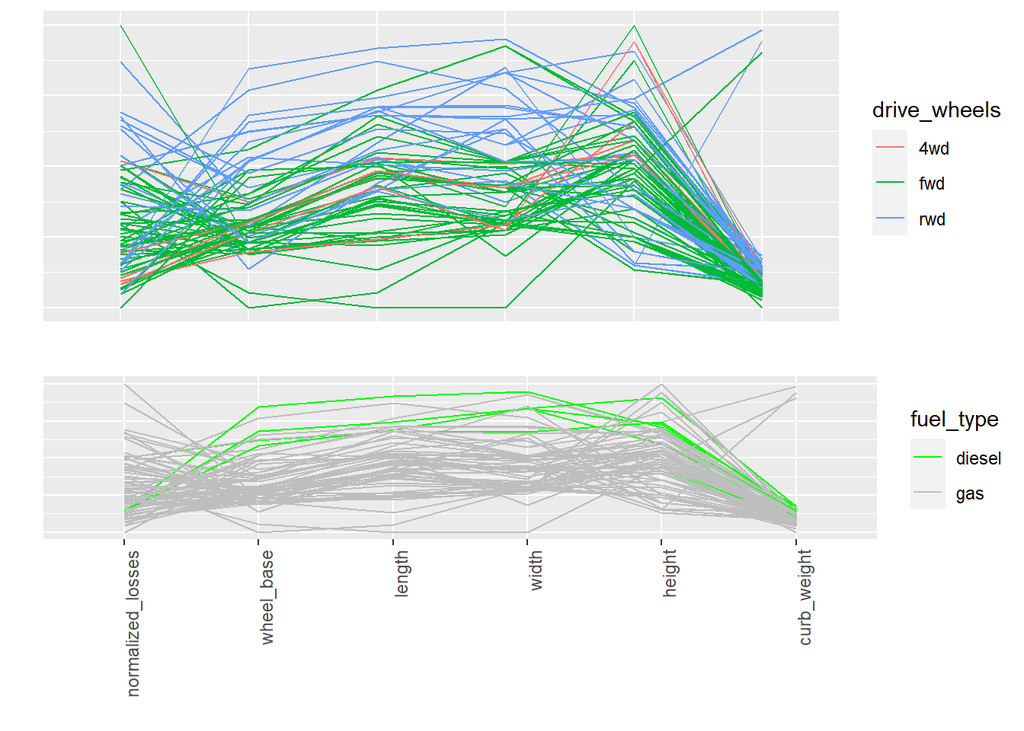

```r
b1 <- ggparcoord(log_imp, columns = c(2,10:14), scale="uniminmax",
           groupColumn = "drive_wheels") +
  xlab("") + ylab("") +
  theme(axis.ticks.y = element_blank(),
        axis.ticks.x = element_blank(),
        axis.text.y = element_blank(),
        axis.text.x = element_blank())

b2 <- ggparcoord(log_imp, columns = c(2,10:14), scale="uniminmax",
           groupColumn = "fuel_type") +
  xlab("") + ylab("") +
  theme(axis.ticks.y = element_blank(),
        axis.text.y = element_blank(),
        axis.text.x=element_text(angle=90,hjust=1)) +
  scale_colour_manual(values = c("green","grey"))

b3 <- ggparcoord(symbols[order(symbols$symboling, decreasing=TRUE),],
           columns=c(2,10:14),
           groupColumn="safe", scale="uniminmax") +
  xlab("") + ylab("") +
  theme(axis.ticks.y = element_blank(),
        axis.text.y = element_blank(),
        axis.text.x=element_text(angle=90,hjust=1)) +
  scale_colour_manual(values = c("red","grey"))


c1 <- ggparcoord(log_imp, columns = 19:26, scale="uniminmax",
           groupColumn = "drive_wheels") +
  xlab("") + ylab("") +
  theme(axis.ticks.x = element_blank(),
        axis.text.x = element_blank())

c2 <- ggparcoord(log_imp, columns = 19:26, scale="uniminmax",
           groupColumn = "fuel_type") +
  xlab("") + ylab("") +
  theme(axis.ticks.y = element_blank(),
        axis.text.y = element_blank(),
        axis.text.x=element_text(angle=90,hjust=1)) +
  scale_colour_manual(values = c("green","grey"))

c3 <- ggparcoord(symbols[order(symbols$symboling, decreasing=TRUE),],
           columns=c(19:26),
           groupColumn="safe", scale="uniminmax") +
  xlab("") + ylab("") +
  theme(axis.ticks.y = element_blank(),
        axis.ticks.x = element_blank(),
        axis.text.y = element_blank(),
        axis.text.x=element_text(angle=90,hjust=1)) +
  scale_colour_manual(values = c("red","grey"))

gridExtra::grid.arrange(b1, b2, nrow=2)
```

Los autos con diesel tienen dimensiones más grandes. La tendencia es similar, pero menos marcada, para los autos con `drive_wheels` rwd.

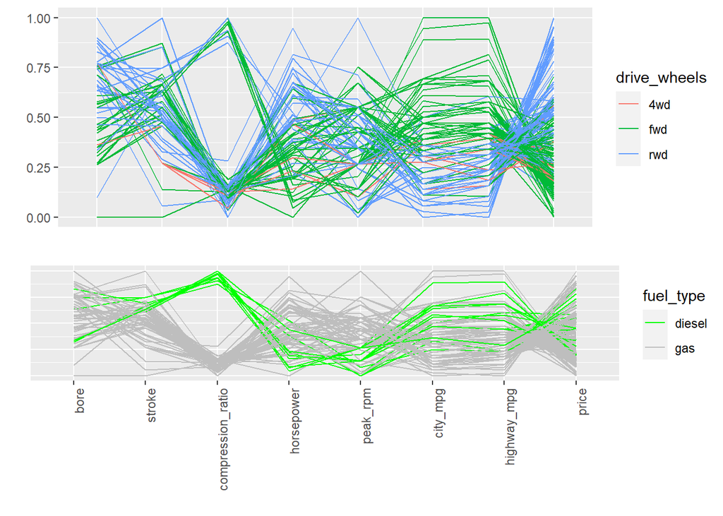

```r
gridExtra::grid.arrange(c1, c2, nrow=2)
```

El segundo grupo de variables se diferencia por lo general en términos de `drive_wheels`, sobre todo fwd y rwd: las observaciones se separan en términos de caballos de fuerza, precio (superiores para rwd) y millas por galón (inferiores para rwd). Los autos con diesel tienen un `compression_ratio` claramente más alto. En cuanto a caballos de fuerza y `peak_rpm`, estos vehículos tienen niveles relativamente bajos. En cuanto al precio, están por encima de la media.

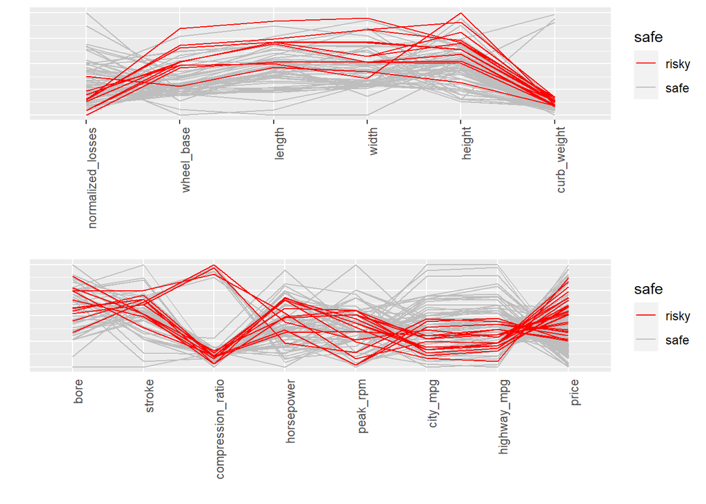

```r
gridExtra::grid.arrange(b3,c3, nrow=2)
```

En cuanto al riesgo asignado, los vehículos riesgosos se caracterizan por ser de mayores dimensiones, tener pérdidas normalizadas menores, un precio por encima de la media, y un rendimiento de la gasolina relativamente bajo.

El segundo tipo de gráficas que examino son las de análisis de componentes principales. Este análisis debe hacerse omitiendo las variables faltantes.

```r
imp.pca <- prcomp(imp_num[complete.cases(imp_num),],
                  center = TRUE, scale. = TRUE)

summary(imp.pca)
```

```
## Importance of components:
##                           PC1    PC2     PC3     PC4     PC5    PC6     PC7
## Standard deviation     2.6819 1.5123 1.20307 0.98469 0.93750 0.7918 0.65223
## Proportion of Variance 0.4795 0.1525 0.09649 0.06464 0.05859 0.0418 0.02836
## Cumulative Proportion  0.4795 0.6320 0.72845 0.79309 0.85169 0.8935 0.92184
##                            PC8     PC9    PC10    PC11    PC12    PC13    PC14
## Standard deviation     0.58371 0.50665 0.41225 0.34899 0.33218 0.29554 0.25166
## Proportion of Variance 0.02271 0.01711 0.01133 0.00812 0.00736 0.00582 0.00422
## Cumulative Proportion  0.94456 0.96167 0.97300 0.98112 0.98848 0.99430 0.99852
##                           PC15
## Standard deviation     0.14894
## Proportion of Variance 0.00148
## Cumulative Proportion  1.00000
```

Procedo a hacer una primera exploración de este gráfico.

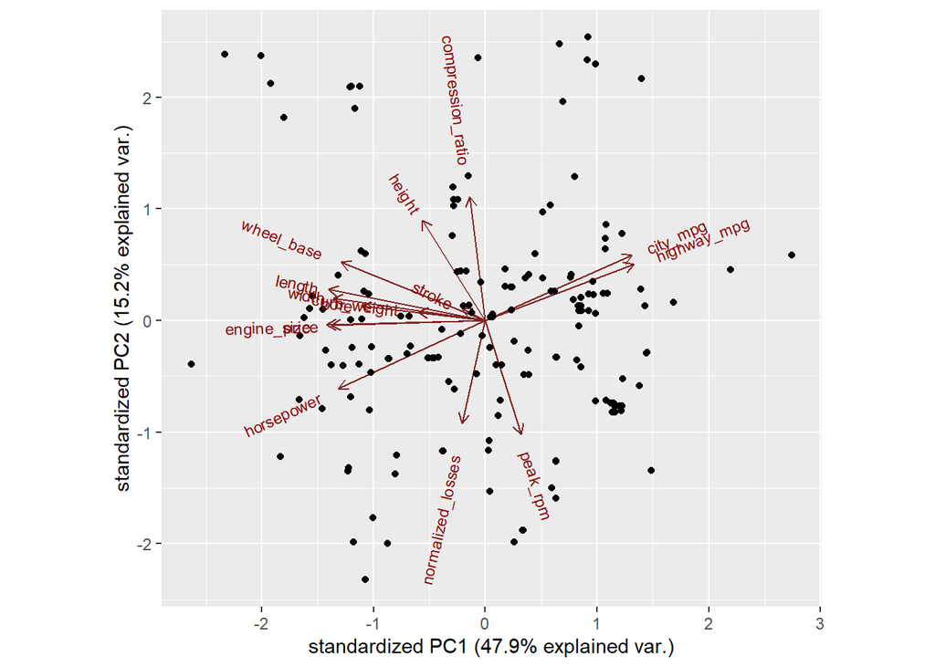

```r
library(devtools)
library(ggbiplot)

ggbiplot(imp.pca)
```

Antes que nada, hacer un PCA con tantas variables dificulta la visualización del gráfico. No obstante, desde esta primera exploración se observan algunos puntos: * `city_mpg` aporta poca variación extra ya considerando a `highway_mpg`, por lo que puede omitirse una de las variables sin una pérdida significativa de variación en los datos. * `width` y `ln_curb_weight` igual pueden omitirse porque son parecidas a `length`. * `ln_engine_size` es casi igual a `ln_price` en el gráfico. Esto es un hallazgo importante, pues nos habla de una colinealidad alta entre estas variables y un potencial predictor del precio en la etapa del modelado. * `stroke` añade muy poca variación a la muestra, así que también la quito para el análisis subsecuente.

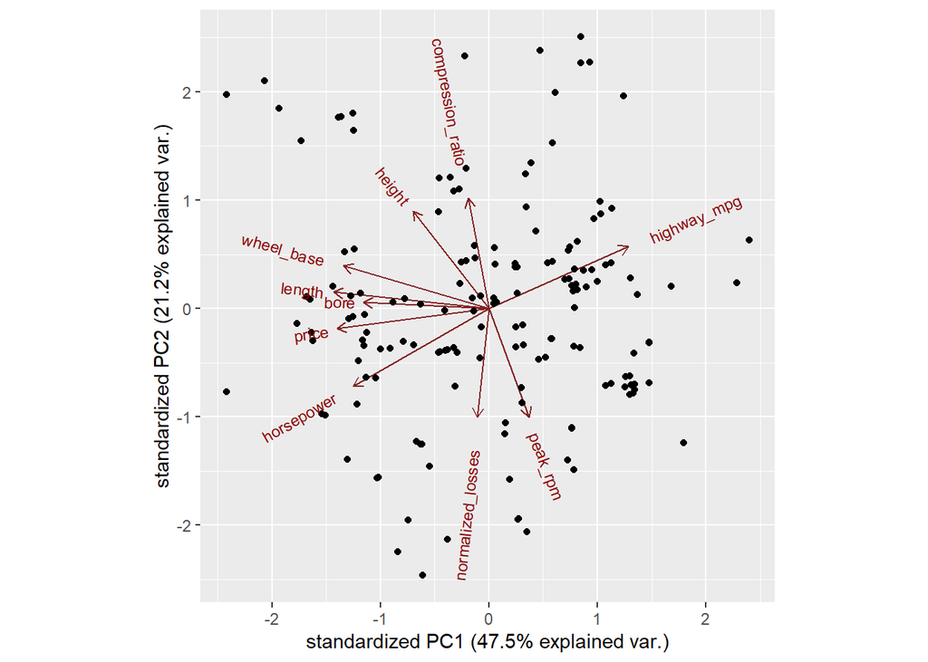

```r
imp.pca <- prcomp(imp_num[complete.cases(imp_num),-c(4,6,7,9,13)],
                  center = TRUE, scale. = TRUE)

ggbiplot(imp.pca)
```

En contraste con el primer gráfico de PCA, los componentes 1 y 2 capturan más varianza. Esto se debe a que, al omitir las otras variables, la varianza de la muestra se redujo en menor medida que la capturada por el modelo. Además, en este modelo se ve más claramente que la combinación lineal de `highway_mpg`, `ln_horsepower`, `ln_price`, `bore`, `length` y `wheel_base` son las variables que más varianza aportan dentro del primer componente, que a su vez es el más predictivo.

Finalmente, agrego información de las variables categóricas al análisis al examinar la presencia de clusters en el PCA. Muestro lo correspondiente para las variables `symboling`, `fuel_system` y `engine_type`.

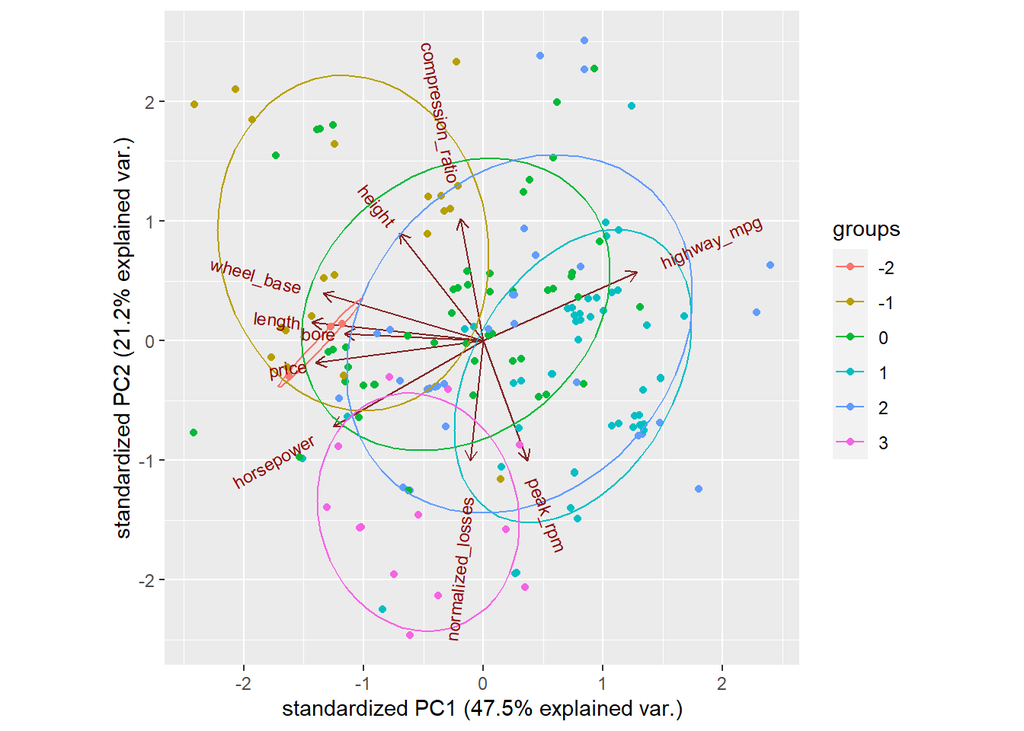

```r
# por symboling.
ggbiplot(imp.pca, ellipse = TRUE, groups = imp_fac$symboling[complete.cases(imp_num)])
```

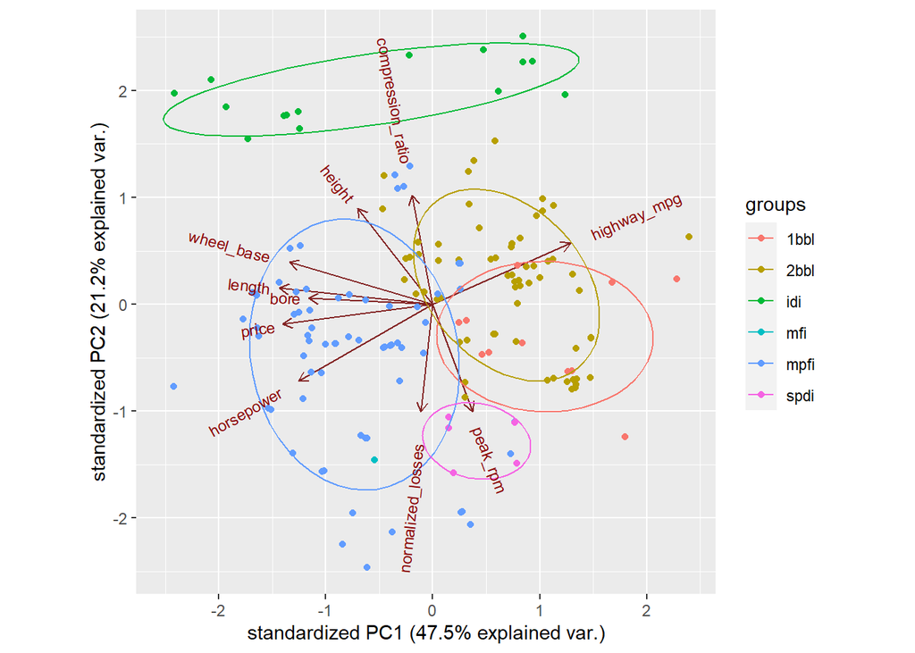

```r
# fuel_system
ggbiplot(imp.pca, ellipse = TRUE, groups = imp_fac$fuel_system[complete.cases(imp_num)])
```

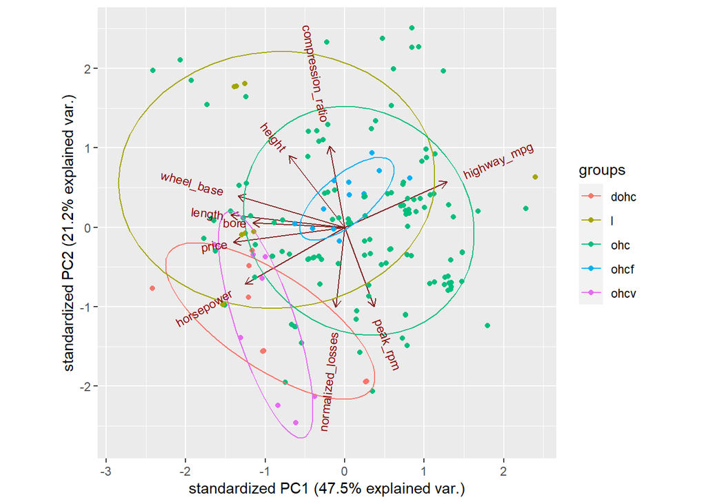

```r
# engine_type.
ggbiplot(imp.pca, ellipse = TRUE, groups = imp_fac$engine_type[complete.cases(imp_num)])
```